# Why You Shouldn’t Peek at Your A/B Test

Simulating Key Ideas from Classical Frequentist Statistics

Author

Shivang Bhatt

Published

April 15, 2026

## Introduction

Imagine you run a website and the landing page includes a small box at the bottom inviting visitors to sign up for your newsletter. The copy you put in that box — the *call to action*, or CTA — matters more than most people think. A single extra word, a nudge in tone, or a change from passive to active voice can meaningfully shift how many people click through. The trouble is you don’t know in advance which phrasing will work better, and your gut feeling is notoriously unreliable.

Suppose you’re deciding between two candidates:

- **CTA A:** “Sign up for our newsletter here!”
- **CTA B:** “Stay up to date by signing up!”

The standard way to settle this kind of question is an *A/B test*. The mechanics are simple: each visitor is randomly assigned to see one of the two CTAs, you record whether they sign up, and at the end you compare the two sign-up rates. Because the assignment is random, any systematic difference between the two groups can be attributed to the CTA itself and not to some underlying difference between the people who saw each version.

This post walks through the statistical machinery that makes A/B testing work. We’ll simulate an A/B test where we know the ground truth, watch our estimator converge to it, quantify our uncertainty two different ways, check that the Central Limit Theorem delivers what it promises, run a formal hypothesis test, show that the same test can be rewritten as a regression, and finish with a cautionary simulation about why peeking at your results early can get you into real trouble.

## The A/B Test as a Statistical Problem

Before we can analyze anything, we need to be precise about what we’re measuring. Each visitor either signs up or they don’t, so their outcome is a single binary event. We can model each visitor’s outcome as a draw from a **Bernoulli distribution** with parameter $\pi$, the probability of signing up.

Because the CTA a visitor sees may influence their probability of signing up, we allow that parameter to differ between the two groups. Visitors who see CTA A have sign-up probability $\pi_A$, and visitors who see CTA B have sign-up probability $\pi_B$. Each individual outcome $X_i$ is either 1 (signed up) or 0 (did not sign up).

The quantity we actually care about is the difference between the two rates:

$$\theta = \pi_A - \pi_B$$

If $\theta > 0$, CTA A is the better performer. If $\theta < 0$, CTA B wins. If $\theta = 0$, the two are equally effective and the wording doesn’t matter for this outcome.

We never get to observe $\pi_A$ and $\pi_B$ directly — those are properties of the underlying population. What we *can* observe are the sample sign-up rates from our experiment. Our estimator of $\theta$ is the difference in sample means:

$$\hat\theta = \bar{X}_A - \bar{X}_B$$

Since each observation is 0 or 1, the sample mean in each group is just the proportion of visitors who signed up, so $\bar{X}_A = \hat\pi_A$ and $\bar{X}_B = \hat\pi_B$. Everything that follows is about understanding how well $\hat\theta$ approximates $\theta$, and what we can say about $\theta$ given only our observed data.

## Simulating Data

In the real world we’d never know the true values of $\pi_A$ and $\pi_B$ — that’s the whole reason we’re running the experiment. But for the purpose of studying how our estimator *behaves*, it helps enormously to work in a setting where we’ve set the truth ourselves. That way we can check whether the methods actually recover what we put in.

For this exercise I’ll assume:

- $\pi_A = 0.22$
- $\pi_B = 0.18$
- so the true difference is $\theta = 0.04$ (four percentage points in A’s favor)

I simulate 1,000 draws from each Bernoulli distribution — so 2,000 synthetic visitors in total, 1,000 per CTA.

```python
rng = np.random.default_rng(42)

pi_A = 0.22
pi_B = 0.18
n    = 1000

X_A = rng.binomial(1, pi_A, size=n)
X_B = rng.binomial(1, pi_B, size=n)

# Observed sample proportions and estimator
pi_hat_A  = X_A.mean()
pi_hat_B  = X_B.mean()
theta_hat = pi_hat_A - pi_hat_B
```

| Quantity | Symbol | Value |
| --- | --- | --- |
| Sample size per group | n | 1,000 |
| True sign-up rate (A) | π_A | 0.220 |
| True sign-up rate (B) | π_B | 0.180 |
| True difference | θ | +0.040 |
| Observed sign-up rate (A) | π̂_A | 0.224 |
| Observed sign-up rate (B) | π̂_B | 0.199 |
| Estimated difference | θ̂ | +0.025 |

On this particular simulation the observed gap comes in at $\hat\theta = \+0\.025$ — noticeably smaller than the true $\theta = 0.04$. That isn’t a bug; it’s exactly the kind of sampling noise the rest of this post is about. With only 1,000 visitors per group and fairly low sign-up rates, random variation can pull our estimate meaningfully off the truth in either direction. The rest of this post is essentially a tour of the classical statistical tools we use to reason about that noise.

## The Law of Large Numbers

The **Law of Large Numbers** (LLN) is the reason averages work at all. It says that as the sample size grows, the sample mean converges to the population mean. Tied back to our setting: the more visitors we include in each group, the closer $\hat\theta = \bar{X}_A - \bar{X}_B$ gets to the true $\theta$. Without the LLN, there’d be no principled reason to trust an average of 10,000 observations any more than an average of 10.

A nice way to see this in action is to compute the *cumulative* average of the paired differences as we walk through our 1,000 observations one at a time, and watch it settle down.

```python
# Element-wise differences, then running average
pair_diffs = X_A - X_B
cum_avg    = np.cumsum(pair_diffs) / np.arange(1, len(pair_diffs) + 1)
```

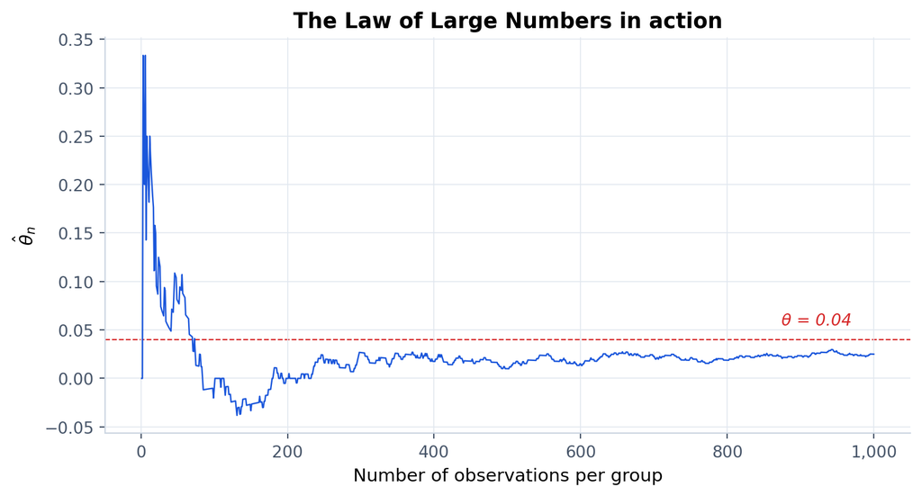

Running average of paired differences. The red dashed line is the true θ = 0.04.

The practical takeaway is that small samples lie to you, confidently and without warning. The LLN is a promise about what happens *eventually*, not a guarantee about what you’ll see at $n = 30$ — or even, as we’re seeing here, at $n = 1{,}000$.

## Bootstrap Standard Errors

Knowing that $\hat\theta$ *eventually* converges is reassuring, but in practice we stop collecting data at some finite $n$ and we need to communicate how much uncertainty is baked into our point estimate. That’s what a **standard error** is for — and one of the most flexible ways to compute one is the **bootstrap**.

The bootstrap is a resampling trick. The intuition goes like this: our observed sample is the best window we have into the population, so we treat it *as if* it were the population, draw new samples from it (with replacement), and recompute our statistic on each of those new samples. The spread of those recomputed statistics gives us a data-driven estimate of how much our statistic would vary from one real sample to another. No closed-form formula, no distributional assumptions beyond what’s already baked into the data.

```python
rng = np.random.default_rng(42)
B = 1000
theta_boot = np.empty(B)

for b in range(B):
    A_star = rng.choice(X_A, size=n, replace=True)
    B_star = rng.choice(X_B, size=n, replace=True)
    theta_boot[b] = A_star.mean() - B_star.mean()

se_boot = theta_boot.std(ddof=1)

# Analytical SE for the difference in two independent Bernoulli proportions
se_analytic = np.sqrt(
    pi_hat_A * (1 - pi_hat_A) / n +
    pi_hat_B * (1 - pi_hat_B) / n
)

# 95% CI using the bootstrap SE
ci_lo = theta_hat - 1.96 * se_boot
ci_hi = theta_hat + 1.96 * se_boot
```

| Quantity | Value |
| --- | --- |
| Point estimate θ̂ | 0.0250 |
| Bootstrap SE | 0.0186 |
| Analytical SE | 0.0183 |
| 95% CI (lower) | -0.0115 |
| 95% CI (upper) | 0.0615 |

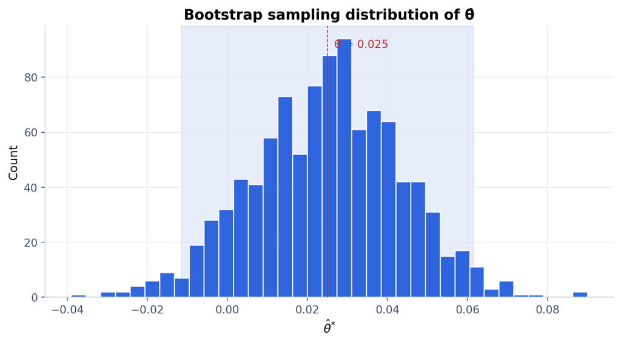

Distribution of 1,000 bootstrap replicates of θ̂. The dashed line is the point estimate; shaded band is the 95% CI.

The two standard errors are strikingly close — the bootstrap lands within a few ten-thousandths of the analytical formula. That’s the point: the bootstrap reproduces, via brute-force computation, what a textbook plug-in formula gives us in closed form. What makes it valuable is that the *same procedure* works for statistics where no clean formula exists.

Using the bootstrap SE, the 95% confidence interval for $\theta$ is roughly $[\-0\.012, 0\.062]$. The interpretation is the standard frequentist one: if we repeated this experiment many times and computed an interval the same way each time, about 95% of those intervals would contain the true $\theta$. Notice the interval does include zero — which is a first hint that, *on this particular simulation*, we may not have enough data to confidently distinguish between the two CTAs, even though we happen to know the truth is $\theta = 0.04$. That’s exactly the story the formal hypothesis test will tell in a couple of sections.

## The Central Limit Theorem

The bootstrap gave us a sampling distribution empirically. The **Central Limit Theorem** (CLT) tells us something stronger: for large enough $n$, we don’t even need the bootstrap — the sampling distribution of $\hat\theta$ is *approximately Normal*, no matter what the underlying distribution of the data looks like. Our data here are Bernoulli, which is about as un-Normal as a distribution gets (it takes only two values), but the CLT doesn’t care. Sum enough of them and the distribution of the sum — or the mean — smooths out into a bell curve.

To see this concretely, I’ll draw 1,000 independent experiments at each of four sample sizes: $n \in \{25, 50, 100, 500\}$. For each experiment I compute $\hat\theta$, then plot the resulting distribution.

```python
rng = np.random.default_rng(42)
sample_sizes = [25, 50, 100, 500]
n_reps = 1000

clt_results = {}
for ss in sample_sizes:
    thetas = np.empty(n_reps)
    for i in range(n_reps):
        a = rng.binomial(1, pi_A, size=ss)
        b = rng.binomial(1, pi_B, size=ss)
        thetas[i] = a.mean() - b.mean()
    clt_results[ss] = thetas
```

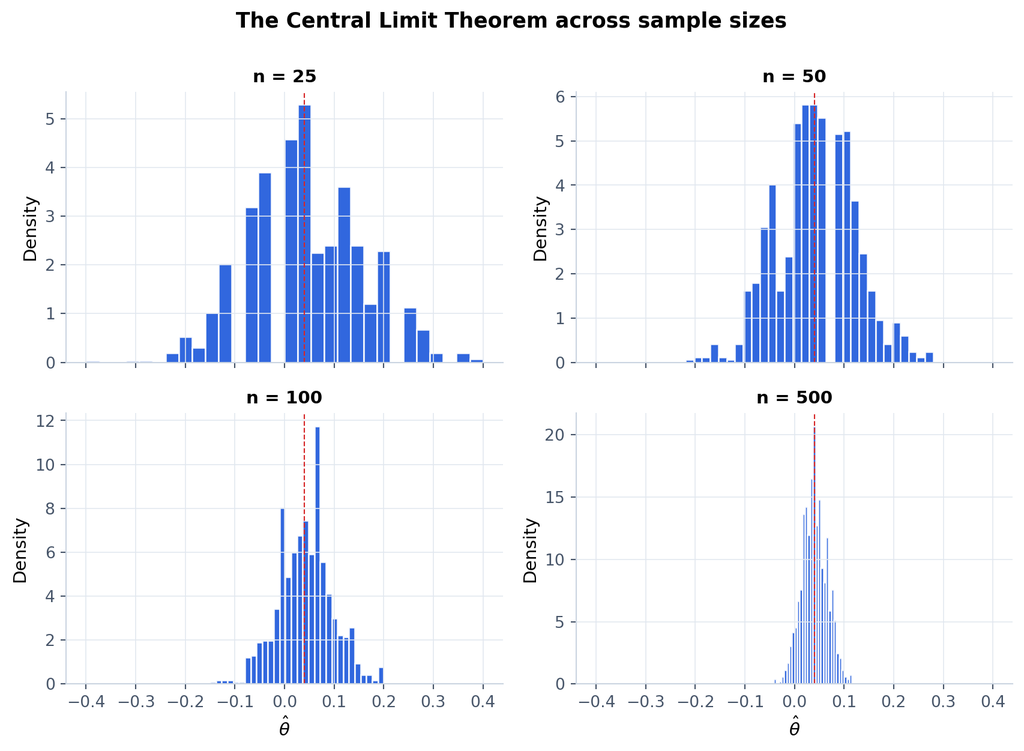

Sampling distributions of θ̂ at four sample sizes. The curve smooths out and tightens around θ = 0.04 as n grows.

At $n = 25$ the distribution is chunky and discrete — you can almost count the possible values of $\hat\theta$, and it’s visibly lumpy. At $n = 50$ things start to look more continuous. By $n = 100$ the shape is clearly bell-like, and at $n = 500$ it’s a tight, symmetric Normal centered almost exactly on the true $\theta = 0.04$. Two things are happening at once in that sequence: the distribution is becoming more Normal-shaped (the CLT), and it’s getting narrower (the LLN, since larger $n$ shrinks the standard error). Both effects compound, which is why larger experiments give you both more precise *and* more Normally-behaved estimates.

## Hypothesis Testing

Armed with the CLT, we can do formal inference. A **hypothesis test** is a structured way of asking: *is my observed result far enough from some baseline to rule out chance as the explanation?* We set up two competing claims:

- $H_0: \theta = 0$ — the null hypothesis, that the two CTAs produce the same sign-up rate
- $H_1: \theta \neq 0$ — the alternative, that they differ

Then we ask: assuming the null is true, how unusual is the $\hat\theta$ we actually observed?

To answer that we standardize $\hat\theta$ into a test statistic:

$$z = \frac{\hat\theta - 0}{\widehat{SE}(\hat\theta)}$$

The logic of this step is worth spelling out carefully:

1. The CLT tells us $\hat\theta$ is approximately Normal for large $n$.
2. Under $H_0$, the mean of that Normal distribution is $0$.
3. Dividing any Normal random variable by its standard deviation produces a standard Normal, so under $H_0$ our test statistic $z \overset{\cdot}{\sim} N(0, 1)$.

Knowing the distribution of $z$ under the null is exactly what lets us compute a **p-value** — the probability of seeing a test statistic at least as extreme as ours if the null were actually true.

One note on terminology. This procedure is often called a “t-test,” which is slightly misleading in our context. The classical t-test is the exact test that arises when your data are drawn from a *Normal* distribution and you have to estimate the variance from the sample; in that case the ratio above follows a t-distribution exactly. Our data are Bernoulli, not Normal, so there’s no exact t-distribution result here — what we have instead is *approximate* Normality via the CLT. Since we estimate the SE from the data, what we’re really doing is closer to a z-test. In practice the distinction rarely matters: for anything beyond very small samples the t-distribution and the standard Normal are nearly indistinguishable. But it’s worth knowing what the mathematical scaffolding actually is.

```python
z_stat  = theta_hat / se_analytic
p_value = 2 * (1 - stats.norm.cdf(abs(z_stat)))
decision = "Reject H₀" if p_value < 0.05 else "Fail to reject H₀"
```

| Quantity | Value |
| --- | --- |
| θ̂ | 0.0250 |
| SE(θ̂) | 0.0183 |
| z-statistic | 1.370 |
| p-value (two-sided) | 0.1708 |
| Decision at α = 0.05 | Fail to reject H₀ |

The test statistic comes in at $z = 1\.370$ with a two-sided p-value of $0\.1708$. That’s *above* the conventional $\alpha = 0.05$ threshold, so we **fail to reject** the null hypothesis. On this particular sample, we don’t have enough evidence to conclude the two CTAs differ — even though, by construction, we know they do.

This is a useful moment to sit with. The underlying truth is $\theta = 0.04$ — there really *is* a four-percentage-point gap between the CTAs — but 1,000 visitors per group, combined with unlucky sampling variation, produced an observed gap small enough that a standard test can’t distinguish it from zero. This is a **Type II error** (failing to detect a real effect), and it highlights a point that often gets glossed over: a non-significant result doesn’t mean “the CTAs are the same.” It means “we didn’t have the data to tell.” A practical consequence for A/B testing is that you should think hard about your sample size *before* running the test — the required $n$ grows quickly as the effect you want to detect shrinks.

## The T-Test as a Regression

Here’s a fact that comes as a surprise to many people the first time they encounter it: the two-sample test we just ran is mathematically equivalent to a simple linear regression. That’s not a coincidence or a curiosity — it’s a consequence of what the least-squares estimator actually does when your single predictor is a 0/1 indicator variable.

To see the equivalence, stack the two groups into a single dataset. For each observation $i$ we have:

- $Y_i$ — the outcome (1 if they signed up, 0 otherwise)
- $D_i$ — an indicator (1 if they saw CTA A, 0 if they saw CTA B)

Then fit the regression

$$Y_i = \beta_0 + \beta_1 D_i + \varepsilon_i$$

The coefficient interpretations fall out directly:

1. $\beta_0$ is the expected value of $Y_i$ when $D_i = 0$ — the mean of the B group, which estimates $\pi_B$.
2. $\beta_0 + \beta_1$ is the expected value of $Y_i$ when $D_i = 1$ — the mean of the A group, which estimates $\pi_A$.
3. So $\beta_1 = \pi_A - \pi_B = \theta$, and the OLS estimate $\hat\beta_1$ is numerically identical to $\hat\theta = \bar{X}_A - \bar{X}_B$.

```python
Y = np.concatenate([X_A, X_B])
D = np.concatenate([np.ones(n), np.zeros(n)])

X_design = sm.add_constant(D)
model    = sm.OLS(Y, X_design).fit()

beta_0, beta_1 = model.params
se_0,   se_1   = model.bse
t_0,    t_1    = model.tvalues
p_0,    p_1    = model.pvalues
```

| Term | Estimate | Std. Error | t value | p-value |
| --- | --- | --- | --- | --- |
| (Intercept) | 0.1990 | 0.0129 | 15.409 | 0.0000 |
| D (CTA A indicator) | 0.0250 | 0.0183 | 1.369 | 0.1712 |

Compare this to the previous section. The coefficient $\hat\beta_1 = 0\.0250$ matches our earlier $\hat\theta$ exactly — as it has to. The standard error is *very* close to our two-sample SE but not identical: OLS assumes a single pooled variance across both groups, while the two-sample formula we used earlier allows each group to have its own variance. For balanced designs and similar group proportions those two differ only slightly, and in this case the difference is a few ten-thousandths. The t-statistic and p-value are likewise essentially the same, and we’d reach the same conclusion either way.

The reason this equivalence is useful — beyond being a neat piece of algebra — is that the regression framework scales. The moment you want to add a control variable, or interact the treatment with some pre-experimental characteristic, or handle three or four treatment arms instead of two, the two-sample test stops being flexible enough but the regression just absorbs the extension cleanly. For simple cases they produce identical inference; for complex cases only one of them keeps working.

## The Problem with Peeking

Now for a cautionary tale. Suppose your boss is impatient. Rather than waiting for all 2,000 visitors to cycle through, she wants to run the hypothesis test after every 100 visitors per group — so at $n = 100, 200, \ldots, 1000$, for 10 tests in total — and declare a winner the moment any one of them returns a significant result at $\alpha = 0.05$.

This feels reasonable. You’re just looking at the data as it comes in, right? But under classical frequentist statistics it’s a disaster, and the reason goes to the heart of what a p-value actually is.

A single hypothesis test conducted at $\alpha = 0.05$ has, by construction, a 5% probability of rejecting the null when the null is actually true — that’s a false positive, or Type I error. The 5% figure is a guarantee about *one* test. When you run ten tests on accumulating data and stop the instant any one of them crosses the threshold, each peek is another chance to get unlucky. The overall probability that *at least one* of the ten tests produces a spurious rejection is much higher than 5%.

I’ll demonstrate this by constructing a world where the null is known to be true — both CTAs have the same sign-up rate of 0.20 — and seeing how often the peeking procedure falsely declares a difference.

```python
rng = np.random.default_rng(42)

n_experiments = 10_000
peek_points   = np.arange(100, 1001, 100)   # 10 peeks per experiment
n_per_group   = 1000
pi_null       = 0.20
alpha         = 0.05

any_significant = np.zeros(n_experiments, dtype=bool)

for e in range(n_experiments):
    a = rng.binomial(1, pi_null, size=n_per_group)
    b = rng.binomial(1, pi_null, size=n_per_group)

    for k in peek_points:
        pa = a[:k].mean()
        pb = b[:k].mean()
        se = np.sqrt(pa * (1 - pa) / k + pb * (1 - pb) / k)

        if se == 0:  # degenerate peek: both groups all 0s or all 1s
            continue

        z = (pa - pb) / se
        p = 2 * (1 - stats.norm.cdf(abs(z)))

        if p < alpha:
            any_significant[e] = True
            break   # boss would have stopped here

empirical_fpr = any_significant.mean()
```

| Quantity | Value |
| --- | --- |
| Number of simulated experiments | 10,000 |
| True θ (null is true) | 0.00 |
| Nominal α per single test | 0.05 |
| Number of peeks per experiment | 10 |
| Empirical false positive rate under peeking | 0.194 |
| Inflation factor vs. nominal 5% | 3.9× |

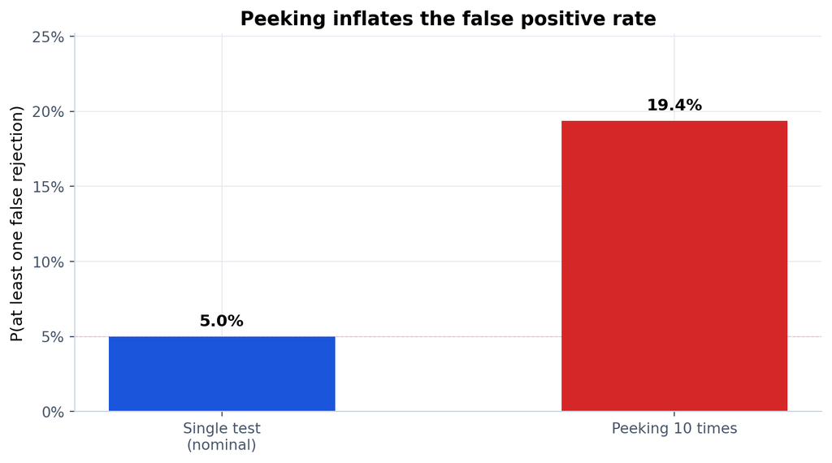

Actual Type I error rate under peeking versus the nominal 5% for a single test.

The nominal false positive rate for a single test is 5%. Under the peeking procedure it climbs to roughly 19.4% — several times higher. In a world where the two CTAs are genuinely identical, almost one in five experiments run under the boss’s protocol would falsely conclude that one CTA is better than the other, purely because the procedure gave random noise ten chances to look like signal instead of one.

The practical consequence for A/B testing is uncomfortable but important. If you run your test with a pre-specified sample size of $n$ and analyze it once, the 5% error rate is a real guarantee. If you keep checking as data rolls in and stop the experiment the moment something crosses significance, that guarantee evaporates. There are legitimate tools for dealing with this — sequential testing procedures, alpha-spending functions, always-valid p-values, Bayesian approaches with proper stopping rules — but applying a vanilla z-test ten times and taking the first “win” isn’t one of them. The discipline of classical A/B testing is in the pre-specification: decide the sample size, run to completion, and analyze once.